# R ile Twitter’dan Nasıl Veri Çekilir?

Veri kaynağı kuştan verilerini nasıl alırız?

Her gün atılan ortalama **500 milyon tweet** ile, Twitter en büyük sosyal medya platformlarından biri. Gün geçtikçe büyüyen ve gündeme bağlı olarak değişen bu devasa içerik, doğru kullanıldığında politikadan magazine kadar çok çeşitli konularda güvenilir bir veri kaynağı olabiliyor.

Bu yazıda Twitter adlı veri madeninden nasıl veri cevheri çıkarabileceğimizi ve bu cevheri nasıl işleyeceğimize göz atacağız. Bu amaçla kullanacağımız R paketinin adı **twitteR**. Bu paket, Twitter üzerindeki içerikleri çekmek için Twitter’ın kendisinin sağlamış olduğu API’leri kullanıyor.

# Kurulum:

Twitter’a erişim için 2 pakete ihtiyacımız bulunuyor. Bunlardan biri twitter’ın web API’sine arayüz sağlayan `twitteR`, diğer ise Twitter hesabımıza R üzerinden erişim yetkisi sağlayacak olan `ROAuth` paketi.

```r
install.packages("twitteR")
install.packages("ROAuth")
```

```r
library("twitteR")
library("ROAuth")
```

# API İzinlerinin Alınması:

Programın Twitter içindeki verileri çekmek için API kullandığından bahsetmiştik. Bu kullanım için bir Twitter hesabınızın olması ve bu hesap üzerinden bir anahtar oluşturmanız gerekecek. Ki bu oldukça kolay bir işlem. Bunun için gerekli basamakları aşağıda belirtiyoruz.

1. https://apps.twitter.com adresine girin.
2. Sağ üst taraftan “**Create New App**” butonuna basın.
3. Açılan sayfada
- **Name** kısmına herhangi bir ad (örneğin “r_twitbot”)
- **Description** herhangi bir açıklama (örneğin “twitteR paketi ile veri madenciliği”)
- **Website** kısmına kodu yayınlayacağınızı ilettiğiniz websitesi (Buraya herhangi bir site yazabilirsiniz.)
- **Callback URL** kısmını boş bırakın ve “*Yes, I have read and agree to the Twitter Developer Agreement.*” kısmına onay verip “**Create your Twitter Application**” butonuna tıklayın.
4. Açılan sayfada *Consumer Key (API Key)* kısmındaki “manage keys and access tokens” bağlantısına tıklayın.

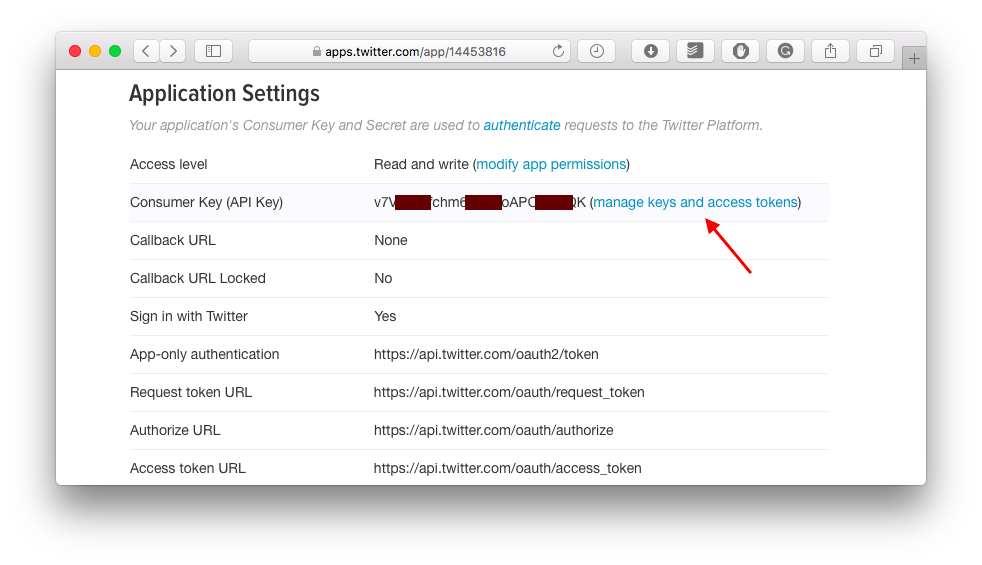

5. Açılan sayfada *Consumer Key (API Key)* ve Consumer Secret (API Secret) değerlerini bir yere not alın.
6. **Your Access Token** başlığı altındaki “**Create my access**” token butonuna tıklayın.

[figure not shown]

7. Sayfanın altında yeni bilgiler oluşacaktır. Bu bilgilerden **Access Token** ve **Access Token Secret** değerlerini de bir yere not alın. **Bu kadar**.

# Uygulama:

## Yetki Verilmesi:

Öncelikle yukarıda, not ettiğimiz yetki değerlerini paketimize tanıtmamız gerekiyor. Bu amaçla kullanacağımız `setup_twitter_oauth()` fonksiyonunu bir defaya özgü olarak çalıştırıyoruz. Aşağıdaki örnekte olduğu gibi not ettiğiniz anahtarları, tırnak içinde uygun parametreye yazıp fonksiyonu çalıştırıyoruz.

```r
setup_twitter_oauth(consumer_key = "buraya Consumer Key (API Key) değeri girilecek",
                    consumer_secret = "buraya Consumer Secret (API Secret) değeri girilecek",
                    access_token = "Buraya Access Token değeri girilecek",
                    access_secret = "Buraya Access Token Secret değeri girilecek")
```

## Belirli Bir Kelimeyi İçeren Tweet’lerin Çekilmesi

Bir hashtag (diyez) veya herhangi başka bir kelime içeren tweetlerin çekilmesi için `searchTwitter()` fonksiyonu kullanılıyor. Çoklu kelime aranacağı zaman `+` operatorü ile ayrılması gerekiyor. Dilenirse lang parametresi ile dil de belirtilebiliyor. `n` parametresi ile kaç tweet çekileceği belirtilebiliyor. Bu parametre için bir sınır olmamasına rağmen Twitter’ın kısıtlamaları sebebiyle her zaman belirttiğiniz kadar tweet çekemeyebiliyorsunuz.

```r
hashtag <- searchTwitter("#rstats", n=2, lang="en")
```

Çekilen tweetler ile ilgili daha fazla veri öğrenmek için `twListToDF()` fonksiyonu ile birlikte de kullanılabilir. Bu fonksiyon, bir tablo oluşturarak her bir tweetin hangi tarihte kim tarafından yayınlandığını, kime cevap olarak mı yazıldığını, kaç defa favori ve retweet aldığını, paylaşılmış ise coğrafi koordinatlarını ve benzeri çok sayıda veriye ulaşmanızı sağlıyor.

```r
twListToDF(hashtag)
```

```
##                                                                                                                                           text
## 1 RT @jakub_nowosad: How can we detect and quantify water quality and cyanobacterial harmful algal bloom (CHABs) from remotely sensed imagery…
## 2                 #rstats just found https://t.co/9GTgwJ1TZu h/t @coolbutuseless  - reminds me how long ago there was… https://t.co/rLCk9BMf39
##   favorited favoriteCount replyToSN             created truncated
## 1     FALSE             0        NA 2018-12-04 10:12:17     FALSE
## 2     FALSE             1        NA 2018-12-04 10:10:33      TRUE
##   replyToSID                  id replyToUID
## 1         NA 1069897168868261890         NA
## 2         NA 1069896731792273408         NA
##                                                         statusSource
## 1 <a href="http://twitter.com" rel="nofollow">Twitter Web Client</a>
## 2 <a href="http://twitter.com" rel="nofollow">Twitter Web Client</a>
##   screenName retweetCount isRetweet retweeted longitude latitude
## 1   andschar            5      TRUE     FALSE        NA       NA
## 2   mdsumner            0     FALSE     FALSE        NA       NA
```

## Bir Kullanıcıya Verilerin Çekilmesi

Bir kullanıcıya ait verilerin çekilmesi için `getUser()` fonksiyonu kullanılır. Bu fonksiyon ile sadece açık profile sahip veya arkadaşınız olarak ekli kişilere erişebileceğinizi de hatırlatmakta fayda var.

```r
twitter_user <- getUser("newscientist")
```

```r
twitter_user$created
```

```
## [1] "2009-01-28 16:05:49 UTC"
```

```r
twitter_user$description
```

```
## [1] "The best place to find out what’s new in science – and why it matters. To subscribe go to: https://t.co/M4DdnmRv4N"
```

```r
twitter_user$favoritesCount
```

```
## [1] 15582
```

```r
head(twitter_user$getFriends(), 3)
```

```
## $`15234407`
## [1] "CERN"
##
## $`20938159`
## [1] "annemarieconlon"
##
## $`50659640`
## [1] "emilyhwilson"
```

## Bir Kullanıcıya Ait Tweetlerin Çekilmesi

Profilini görebildiğiniz bir kullanıcının tweetlerini çekmek için `userTimeline()` fonksiyonunu kullanıyoruz. Benzer şekilde n parametresi ile (en fazla 3200 olacak şekilde) kaç adet tweetinin çekileceğini belirtebiliyorsunuz. (Aslına bakarsanız çoğu kısıtlamalar sebebiyle 3200 de çekemiyorsunuz.) Kaydettiğiniz tweetlerin detaylarını öğrenmek isterseniz `twListToDF()` komutu ile tablo olarak da görebiliyorsunuz.

```r
tweets <- userTimeline("newscientist", n=2)
tweets
```

```
## [[1]]
## [1] "newscientist: Don’t feel sorry for apologising – it could be good for you https://t.co/6LBhbgwDMy https://t.co/WJliPwSe64"
##
## [[2]]
## [1] "newscientist: Evolution is making us sick and for the first time we can stop it https://t.co/xY8xyooK94 https://t.co/6aWQ2QnQV9"
```

```r
twListToDF(tweets)
```

| text | favorited | favoriteCount | replyToSN | created | truncated | replyToSID | id | replyToUID | statusSource | screenName | retweetCount | isRetweet | retweeted | longitude | latitude |
| --- | --- | --- | --- | --- | --- | --- | --- | --- | --- | --- | --- | --- | --- | --- | --- |
| Don’t feel sorry for apologising – it could be good for you https://t.co/6LBhbgwDMy https://t.co/WJliPwSe64 | FALSE | 45 | NA | 2018-12-04 08:05:05 | FALSE | NA | 1069865157248118784 | NA | <a href=“https://www.echobox.com” rel=“nofollow”>Echobox Social</a> | newscientist | 15 | FALSE | FALSE | NA | NA |
| Evolution is making us sick and for the first time we can stop it https://t.co/xY8xyooK94 https://t.co/6aWQ2QnQV9 | FALSE | 56 | NA | 2018-12-04 07:45:33 | FALSE | NA | 1069860240689111040 | NA | <a href=“https://www.echobox.com” rel=“nofollow”>Echobox Social</a> | newscientist | 20 | FALSE | FALSE | NA | NA |

Oluşturacağınız tablodan, kullanıcının hangi saat aralıklarında tweet attığını çıkarabilir, tweetlerinin ortalama kaç defa beğenildiğini, beğenilen tweetlerin ortak kelimelere sahip olup olmadığını inceleyebilirsiniz.

twitteR paketi güncel durumlar ile ilgili bu devasa veri madenine giriş bileti sağlasa da, çok eski tweetlere erişim imkanı vermiyor. Bu durum da tamamen Twitter’ın API’si ile ilgili. Yani, Arap Baharı zamanındaki tweetleri incelemeniz ne yazık ki mümkün değil. Bunun çözümü belki de bir anahtar kelimeye ait düzenli olarak veri çekip kendi veritabanını oluşturmak…

Umarım bu yazı yararlı olmuştur. Gelecek yazılarda bu verilerin nasıl değerlendirileceğine dair veri görselleştirme projelerine yer verebiliriz.

**Can Holyavkin**

E-posta | [Linkedin](https://www.linkedin.com/in/can-holyavkin/) | [Twitter](https://twitter.com/CanHolyavkin)